# Exploring ggplot2 Geoms with Student Performance Data

NGABO Prince

2026-10-31

```r
library(ggplot2)

students <- read.csv("student_scores.csv")

head(students)
```

```
##   student_id gender          program test_number study_hours sleep_hours
## 1        S01   Male Computer Science           1        11.0         7.8
## 2        S01   Male Computer Science           2        10.9         8.8
## 3        S01   Male Computer Science           3        11.9         8.5
## 4        S01   Male Computer Science           4         8.6         8.2
## 5        S02 Female      Engineering           1        13.1         6.6
## 6        S02 Female      Engineering           2        14.6         5.6
##   attendance_pct score
## 1             64    59
## 2             64    63
## 3             64    69
## 4             64    59
## 5             62    69
## 6             62    67
```

```r
str(students)
```

```
## 'data.frame':    120 obs. of  8 variables:
##  $ student_id    : chr  "S01" "S01" "S01" "S01" ...
##  $ gender        : chr  "Male" "Male" "Male" "Male" ...
##  $ program       : chr  "Computer Science" "Computer Science" "Computer Science" "Computer Science" ...
##  $ test_number   : int  1 2 3 4 1 2 3 4 1 2 ...
##  $ study_hours   : num  11 10.9 11.9 8.6 13.1 14.6 11.9 15.8 7.6 4.8 ...
##  $ sleep_hours   : num  7.8 8.8 8.5 8.2 6.6 5.6 5.9 6.2 7.2 7.5 ...
##  $ attendance_pct: int  64 64 64 64 62 62 62 62 77 77 ...
##  $ score         : int  59 63 69 59 69 67 71 77 62 53 ...
```

```r
summary(students)
```

```
##      student_id        gender         program     test_number    study_hours
##  Length   :120   Length   :120   Length   :120   Min.   :1.00   Min.   : 2.30
##  N.unique : 30   N.unique :  2   N.unique :  3   1st Qu.:1.75   1st Qu.: 8.60
##  N.blank  :  0   N.blank  :  0   N.blank  :  0   Median :2.50   Median :13.20
##  Min.nchar:  3   Min.nchar:  4   Min.nchar:  8   Mean   :2.50   Mean   :12.57
##  Max.nchar:  3   Max.nchar:  6   Max.nchar: 16   3rd Qu.:3.25   3rd Qu.:16.50
##                                                  Max.   :4.00   Max.   :22.00
##   sleep_hours    attendance_pct      score
##  Min.   :4.400   Min.   :60.00   Min.   : 39.00
##  1st Qu.:6.175   1st Qu.:66.00   1st Qu.: 60.00
##  Median :7.100   Median :76.00   Median : 71.00
##  Mean   :7.067   Mean   :77.23   Mean   : 70.01
##  3rd Qu.:7.900   3rd Qu.:88.00   3rd Qu.: 79.25
##  Max.   :9.500   Max.   :99.00   Max.   :100.00
```

Some plots need one row per student instead of one row per test, so we also keep only the first test:

```r
students_t1 <- subset(students, test_number == 1)
nrow(students_t1)
```

```
## [1] 30
```

# 1. geom_bar()

- `geom_bar()`
- Draws a bar chart where the bar height is the **count** of rows in each category.
- Counting how many students are in each program, split by gender.

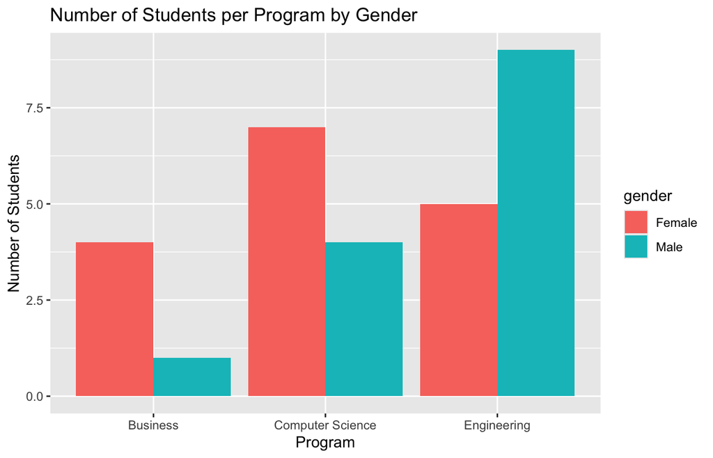

```r
ggplot(students_t1, aes(x = program, fill = gender)) +
  geom_bar(position = "dodge") +
  labs(title = "Number of Students per Program by Gender",
       x = "Program", y = "Number of Students")
```

# 2. geom_boxplot()

- `geom_boxplot()`
- Shows the distribution of a numeric variable with the median, quartiles (box), whiskers, and outliers.
- Comparing test scores across the three programs.

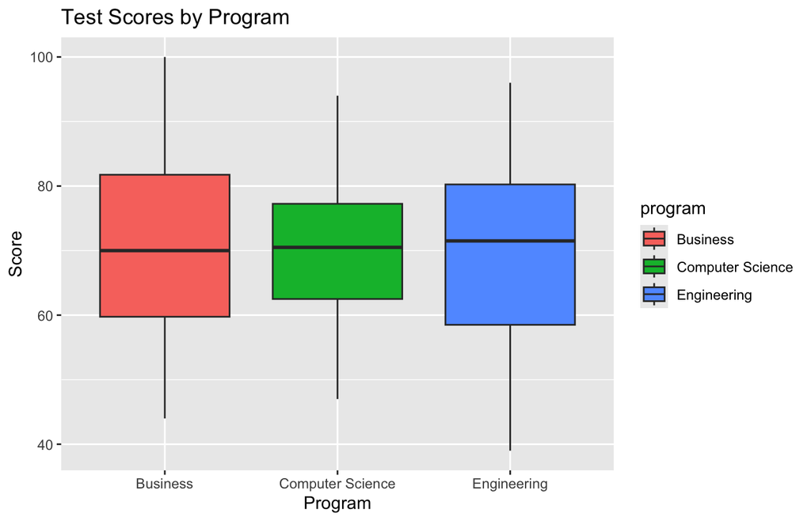

```r
ggplot(students, aes(x = program, y = score, fill = program)) +
  geom_boxplot() +
  labs(title = "Test Scores by Program",
       x = "Program", y = "Score")
```

# 3. geom_density()

- `geom_density()`
- Draws a smooth curve showing the distribution of a numeric variable.
- Comparing how many hours of sleep female and male students get.

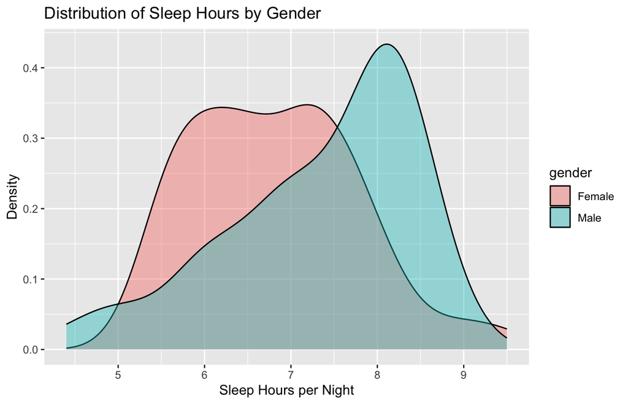

```r
ggplot(students, aes(x = sleep_hours, fill = gender)) +
  geom_density(alpha = 0.4) +
  labs(title = "Distribution of Sleep Hours by Gender",
       x = "Sleep Hours per Night", y = "Density")
```

# 4. geom_histogram()

- `geom_histogram()`
- Groups a numeric variable into bins and draws bars for how many values fall in each bin.
- Looking at how all the test scores are distributed.

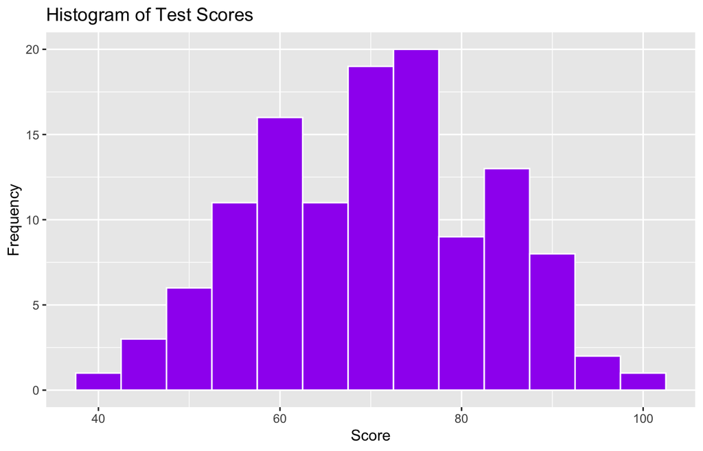

```r
ggplot(students, aes(x = score)) +
  geom_histogram(binwidth = 5, fill = "purple", color = "white") +
  labs(title = "Histogram of Test Scores",
       x = "Score", y = "Frequency")
```

# 5. geom_hline()

- `geom_hline()`
- Adds a **horizontal** reference line at a given y value.
- Plotting every score per test and drawing the pass mark (50) as a red line, so we can see who is above or below it.

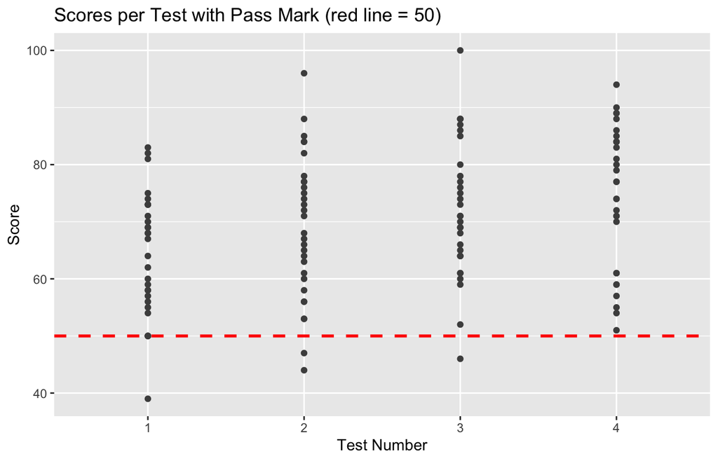

```r
ggplot(students, aes(x = factor(test_number), y = score)) +
  geom_point(color = "gray30") +
  geom_hline(yintercept = 50, color = "red", linetype = "dashed", linewidth = 1) +
  labs(title = "Scores per Test with Pass Mark (red line = 50)",
       x = "Test Number", y = "Score")
```

# 6. geom_jitter()

- `geom_jitter()`
- A scatter plot with a small random shift added to each point so that overlapping points become visible.
- Showing every individual score for each gender without the points stacking on top of each other.

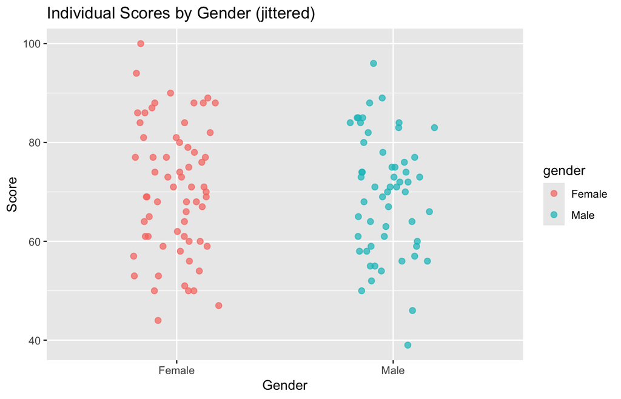

```r
ggplot(students, aes(x = gender, y = score, color = gender)) +
  geom_jitter(width = 0.2, height = 0, size = 2, alpha = 0.7) +
  labs(title = "Individual Scores by Gender (jittered)",
       x = "Gender", y = "Score")
```

# 7. geom_line()

- `geom_line()`
- Connects points with lines in order of the x variable, which shows trends over time or sequence.
- Calculating the average score per test for each program and showing how it changes from test 1 to test 4.

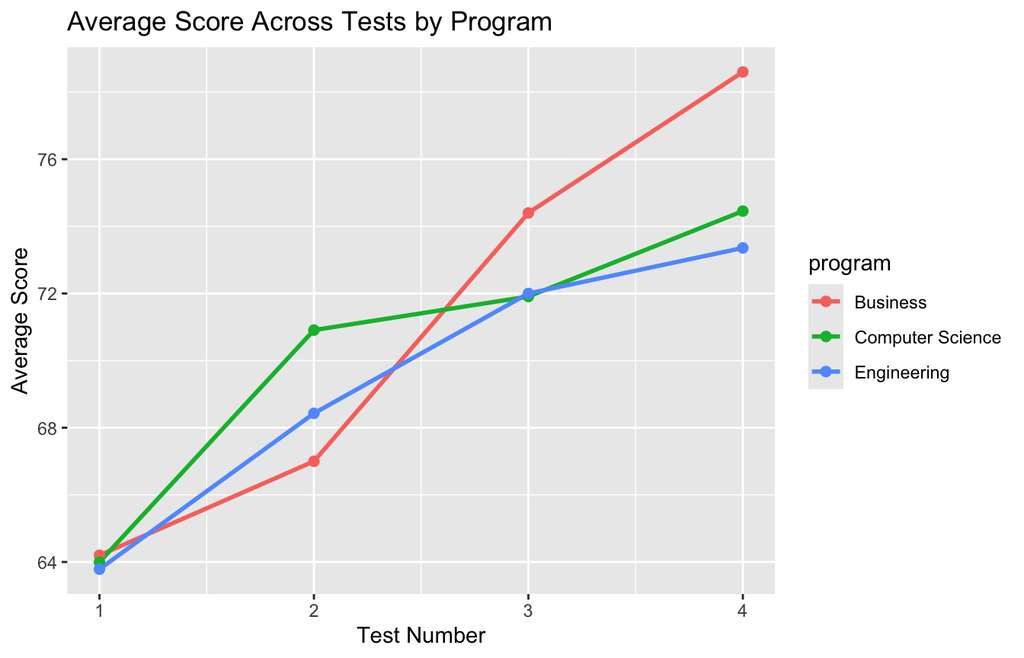

```r
avg_by_test <- aggregate(score ~ test_number + program, data = students, FUN = mean)

ggplot(avg_by_test, aes(x = test_number, y = score, color = program)) +
  geom_line(linewidth = 1) +
  geom_point(size = 2) +
  labs(title = "Average Score Across Tests by Program",
       x = "Test Number", y = "Average Score")
```

# 8. geom_point()

- `geom_point()`
- Creates a scatter plot with one point per row.
- Exploring the relationship between weekly study hours and test score.

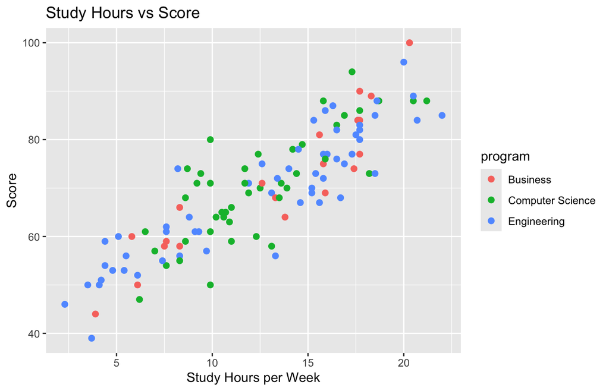

```r
ggplot(students, aes(x = study_hours, y = score, color = program)) +
  geom_point(size = 2) +
  labs(title = "Study Hours vs Score",
       x = "Study Hours per Week", y = "Score")
```

# 9. geom_rug()

- `geom_rug()`
- Adds small tick marks along the axes showing where each data value lies.
- Adding rug marks to the attendance vs score plot to show where attendance and score values are concentrated.

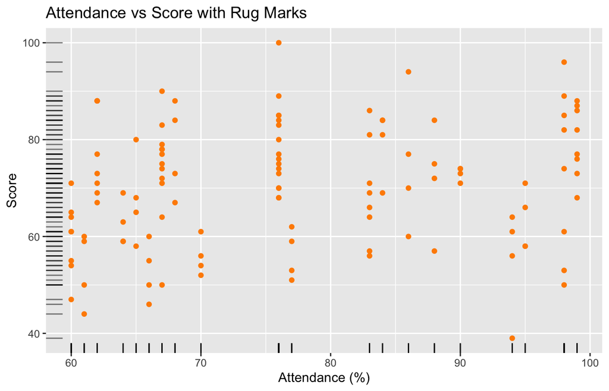

```r
ggplot(students, aes(x = attendance_pct, y = score)) +
  geom_point(color = "darkorange") +
  geom_rug(alpha = 0.5) +
  labs(title = "Attendance vs Score with Rug Marks",
       x = "Attendance (%)", y = "Score")
```

# 10. geom_smooth()

- `geom_smooth()`
- Adds a fitted trend line (linear with `method = "lm"`) with a shaded confidence band.
- Checking whether students who study more hours get higher scores.

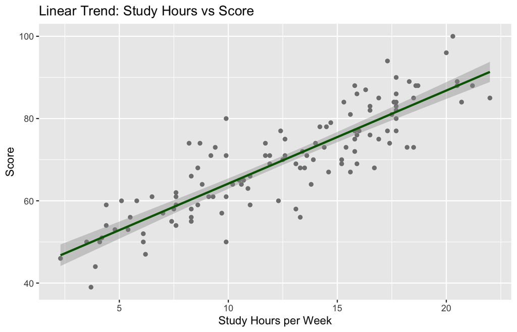

```r
ggplot(students, aes(x = study_hours, y = score)) +
  geom_point(color = "gray50") +
  geom_smooth(method = "lm", color = "darkgreen") +
  labs(title = "Linear Trend: Study Hours vs Score",
       x = "Study Hours per Week", y = "Score")
```

# 11. geom_text()

- `geom_text()`
- Places text labels on a plot at given x/y positions.
- Showing the average score of each program as a bar, with the exact value written on top.

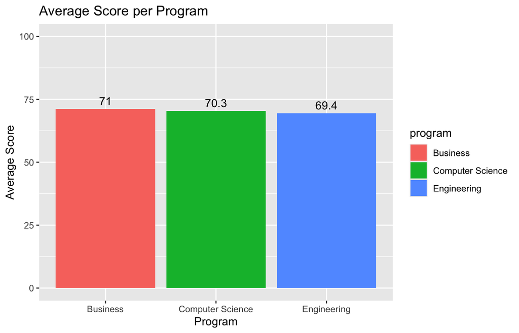

```r
avg_by_program <- aggregate(score ~ program, data = students, FUN = mean)

ggplot(avg_by_program, aes(x = program, y = score, fill = program)) +
  geom_col() +
  geom_text(aes(label = round(score, 1)), vjust = -0.5) +
  ylim(0, 100) +
  labs(title = "Average Score per Program",
       x = "Program", y = "Average Score")
```

# 12. geom_violin()

- `geom_violin()`
- Shows the shape of a distribution for each group; the wider the violin, the more values at that level.
- Comparing the shape of study hours across the three programs.

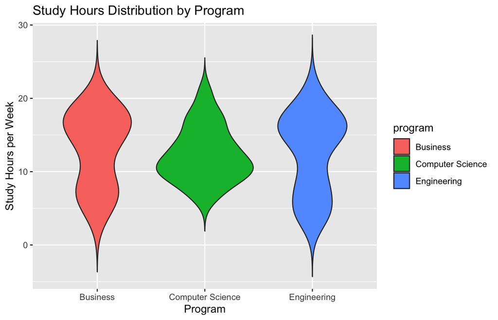

```r
ggplot(students, aes(x = program, y = study_hours, fill = program)) +
  geom_violin(trim = FALSE) +
  labs(title = "Study Hours Distribution by Program",
       x = "Program", y = "Study Hours per Week")
```

# 13. geom_vline()

- `geom_vline()`
- Adds a **vertical** reference line at a given x value.
- Drawing a histogram of study hours and marking the average study hours with a vertical line.

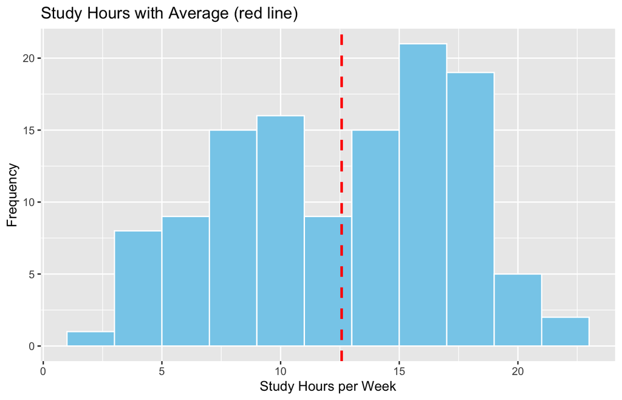

```r
avg_study <- mean(students$study_hours)

ggplot(students, aes(x = study_hours)) +
  geom_histogram(binwidth = 2, fill = "skyblue", color = "white") +
  geom_vline(xintercept = avg_study, color = "red", linewidth = 1, linetype = "dashed") +
  labs(title = "Study Hours with Average (red line)",
       x = "Study Hours per Week", y = "Frequency")
```

# Summary

| Function | What we showed |
| --- | --- |
| `geom_bar()` | Students per program and gender |
| `geom_boxplot()` | Scores by program |
| `geom_density()` | Sleep hours by gender |
| `geom_histogram()` | Distribution of scores |
| `geom_hline()` | Pass mark line on scores |
| `geom_jitter()` | Individual scores by gender |
| `geom_line()` | Average score across tests |
| `geom_point()` | Study hours vs score |
| `geom_rug()` | Attendance and score values on the axes |
| `geom_smooth()` | Trend between study hours and score |
| `geom_text()` | Average score labels on bars |
| `geom_violin()` | Study hours by program |
| `geom_vline()` | Average study hours line |